# Chapter 02 Exercises

There also appears to be a cyclic dip every 8-10 years

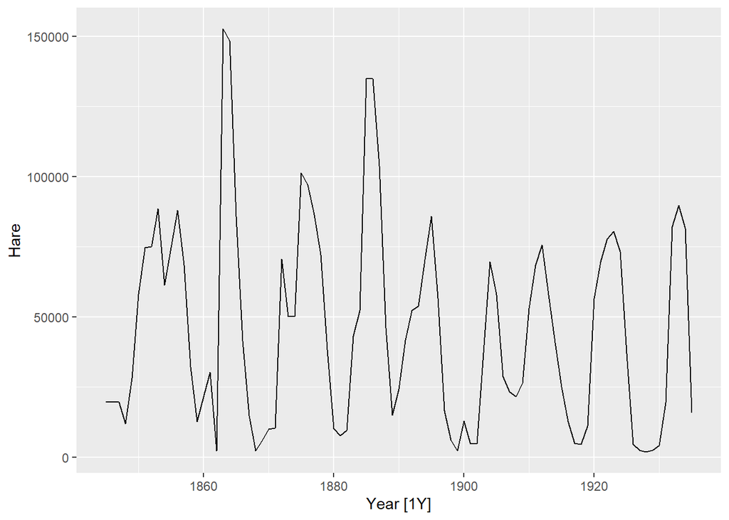

```r
autoplot(pelt,Hare)
```

There does not appear to be a trend, and the data is yearly, so no seasonality. Cyclic pattern every 5-10 years apparent

```
## Plot variable not specified, automatically selected `.vars = total_cost`
```

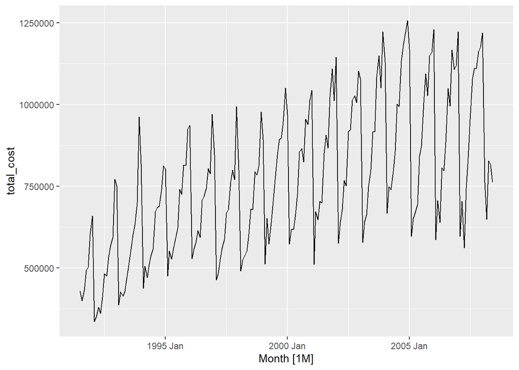

```r
h02_cost <- PBS %>%
  filter(ATC2 == 'H02') %>%
  summarize(total_cost = sum(Cost))


autoplot(h02_cost)
```

11. The `aus_livestock` data contains the monthly total number of pigs slaughtered in Victoria, Australia, from Jul 1972 to Dec 2018. Use `filter()` to extract pig slaughters in Victoria between 1990 and 1995. Use `autoplot()` and `ACF()` for this data. How do they differ from white noise? If a longer period of data is used, what difference does it make to the ACF?

```r
aus_livestock_9095 <- aus_livestock %>%
  filter(Month >= yearmonth('1990 Jan'),
         Month <= yearmonth('1995 Dec'),
         Animal == 'Pigs') %>%
  summarize(Count = sum(Count))

aus_livestock_9095
```

```
## # A tsibble: 72 x 2 [1M]
##       Month  Count
##       <mth>  <dbl>
##  1 1990 Jan 371400
##  2 1990 Feb 377200
##  3 1990 Mar 431300
##  4 1990 Apr 391400
##  5 1990 May 461200
##  6 1990 Jun 430800
##  7 1990 Jul 413900
##  8 1990 Aug 424100
##  9 1990 Sep 406700
## 10 1990 Oct 407700
## # ... with 62 more rows
```

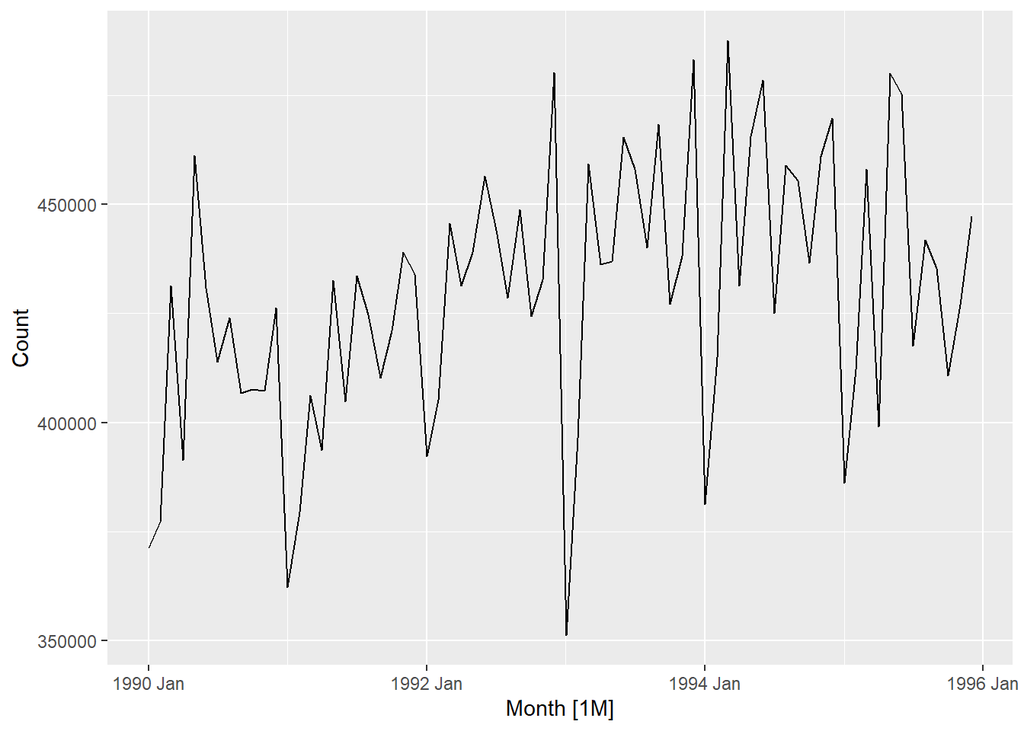

```r
autoplot(aus_livestock_9095, Count)
```

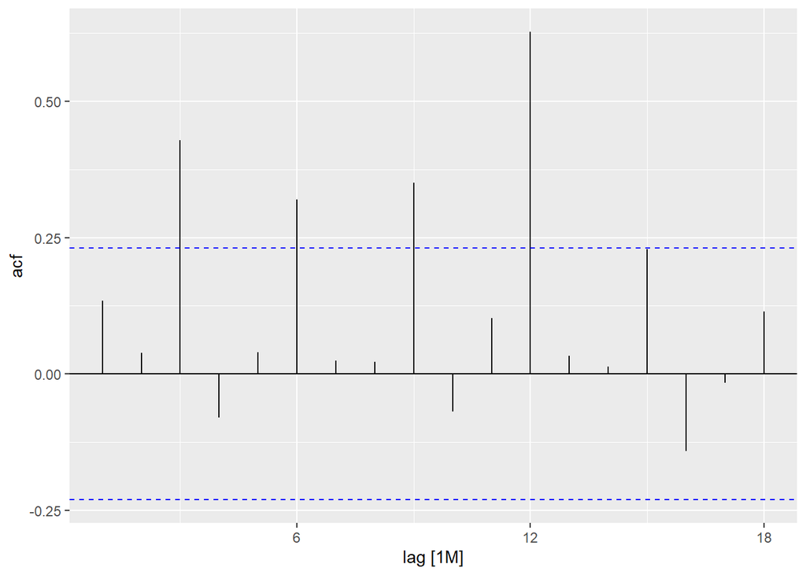

```r
autoplot(ACF(aus_livestock_9095, Count))
```

Definite seasonality and trend. ACF shows autocorrelation as well. This would make it different from white noise.

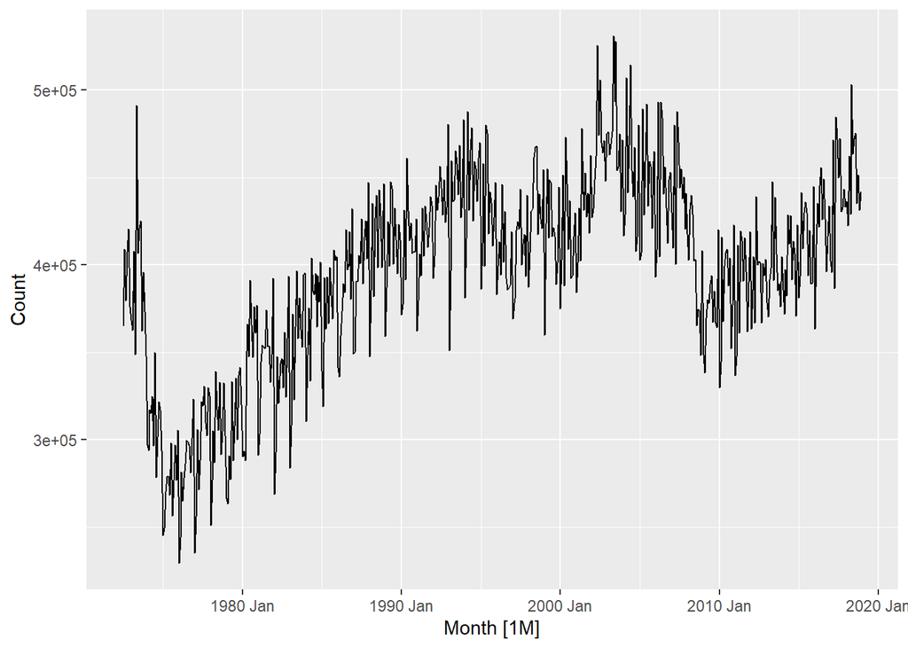

```r
aus_livestock_pigs <- aus_livestock %>%
  filter(Animal == 'Pigs') %>%
  summarize(Count = sum(Count))

autoplot(aus_livestock_pigs, Count)
```

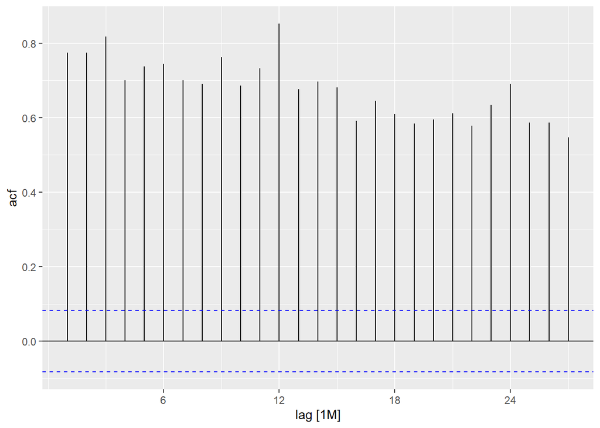

```r
autoplot(ACF(aus_livestock_pigs, Count))
```

The longer time series has a steeper trend making the ACF decrease slightly as the lags increase and there’s a slight scalloped shape due to the seasonality

12. Use the following code to compute the daily changes in Google closing stock prices.
    1. Why was it necessary to re-index the tsibble?
    2. Plot these differences and their ACF.
    3. Do the changes in the stock prices look like white noise?

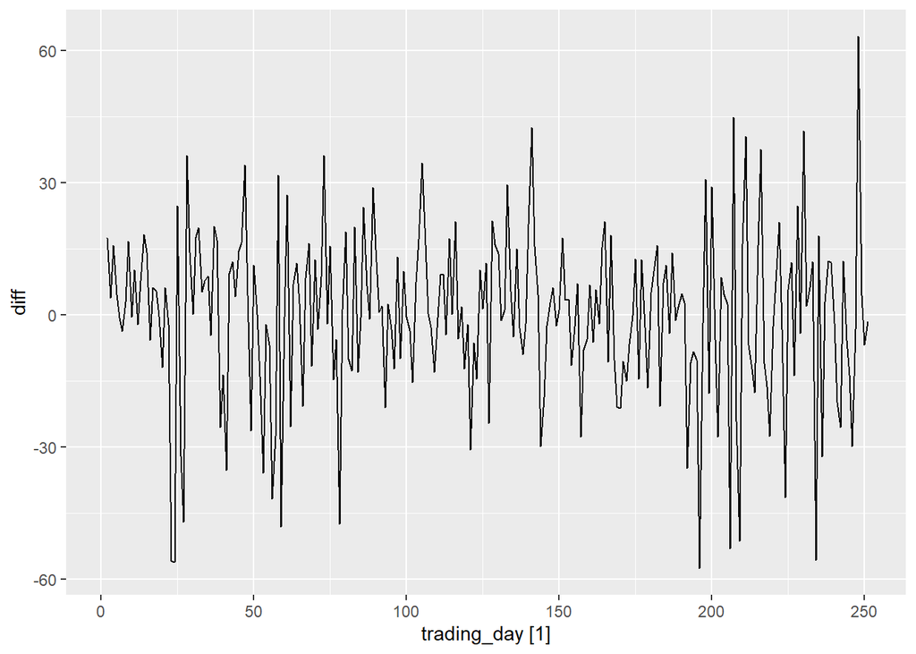

```r
dgoog <- gafa_stock %>%
  filter(Symbol == "GOOG", year(Date) >= 2018) %>%
  mutate(trading_day = row_number()) %>%
  update_tsibble(index = trading_day, regular = TRUE) %>%
  mutate(diff = difference(Close))

autoplot(dgoog, diff)
```

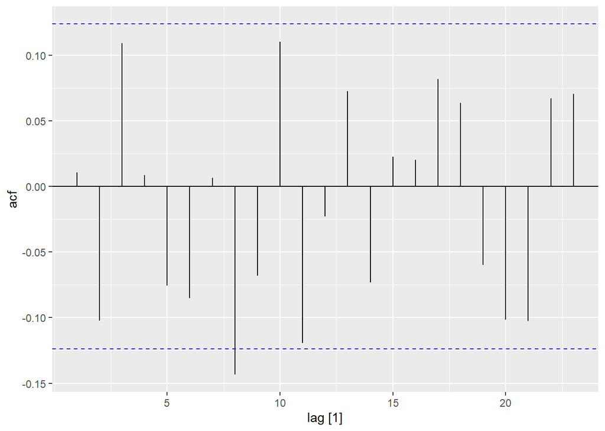

```r
autoplot(ACF(dgoog, diff))
```

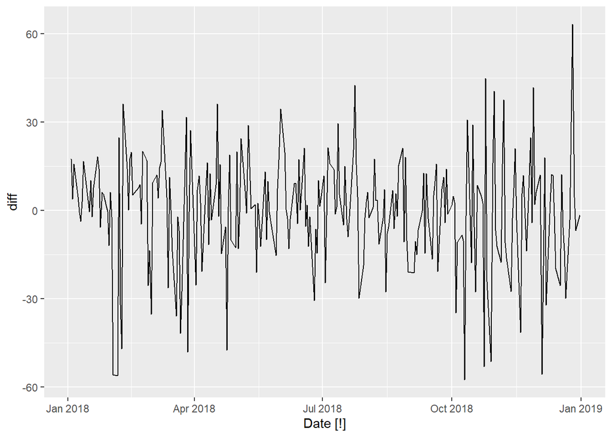

```r
# plotting without updating the index of the tsibble
# both charts look exactly the same except for the x-axis labels
dgoog_no_reindex <- gafa_stock %>%
  filter(Symbol == "GOOG", year(Date) >= 2018) %>%
  mutate(diff = difference(Close))

autoplot(dgoog_no_reindex, diff)
```

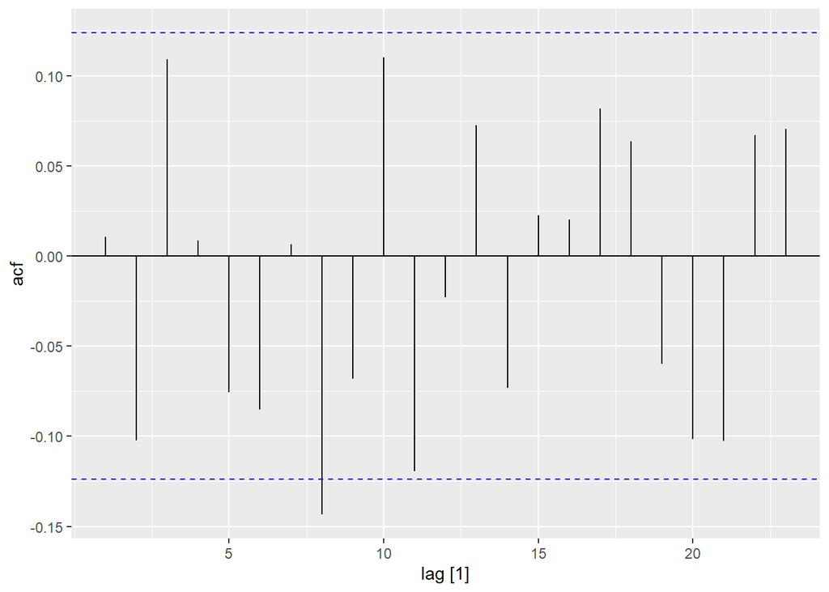

```r
autoplot(ACF(dgoog_no_reindex, diff))
```

- Re-indexing the time series doesn’t seem to be entirely necessary, but the reason for doing it is because trading days are not consistent (as weekends and holidays make irregular gaps the data).
- Yes, the changes in the stock price (and most stock prices) are white noise